# IBM HR Analytics Employee Attrtition & Performance

This notebook is an analytics project to analyze the dataset provdied in the (IBM HR Analytics Employee Attrition & Performance)[https://www.kaggle.com/pavansubhasht/ibm-hr-analytics-attrition-dataset]

The notebook will consist of Exploratory Data Analysis, Cohort Analysis by Attrition and Join Dates, and Prediction of Attrition.

# Library Load

```r
library(dplyr)
library(tidyverse)
```

```r
library(highcharter)
library(randomForest)
library(caret)
library(pROC)
library(magrittr)
library(ggplot2)
library(highcharter)
library(lubridate)
library(prophet)
library(ModelMetrics)
library(caTools)
library(rpart)
library(rpart.plot)
library(ROCR)
```

# Data Import

```r
data <- read.csv('WA_Fn-UseC_-HR-Employee-Attrition.csv')
head(data)
```

|  | 癤풞ge | Attrition | BusinessTravel | DailyRate | Department | DistanceFromHome | Education | EducationField | EmployeeCount | EmployeeNumber | EnvironmentSatisfaction | Gender | HourlyRate | JobInvolvement | JobLevel | JobRole | JobSatisfaction | MaritalStatus | MonthlyIncome | MonthlyRate | NumCompaniesWorked | Over18 | OverTime | PercentSalaryHike | PerformanceRating | RelationshipSatisfaction | StandardHours | StockOptionLevel | TotalWorkingYears | … |
| --- | --- | --- | --- | --- | --- | --- | --- | --- | --- | --- | --- | --- | --- | --- | --- | --- | --- | --- | --- | --- | --- | --- | --- | --- | --- | --- | --- | --- | --- | --- |
| 1 | 41 | Yes | Travel_Rarely | 1102 | Sales | 1 | 2 | Life Sciences | 1 | 1 | 2 | Female | 94 | 3 | 2 | Sales Executive | 4 | Single | 5993 | 19479 | 8 | Y | Yes | 11 | 3 | 1 | 80 | 0 | 8 | … |
| 2 | 49 | No | Travel_Frequently | 279 | Research & Development | 8 | 1 | Life Sciences | 1 | 2 | 3 | Male | 61 | 2 | 2 | Research Scientist | 2 | Married | 5130 | 24907 | 1 | Y | No | 23 | 4 | 4 | 80 | 1 | 10 | … |
| 3 | 37 | Yes | Travel_Rarely | 1373 | Research & Development | 2 | 2 | Other | 1 | 4 | 4 | Male | 92 | 2 | 1 | Laboratory Technician | 3 | Single | 2090 | 2396 | 6 | Y | Yes | 15 | 3 | 2 | 80 | 0 | 7 | … |
| 4 | 33 | No | Travel_Frequently | 1392 | Research & Development | 3 | 4 | Life Sciences | 1 | 5 | 4 | Female | 56 | 3 | 1 | Research Scientist | 3 | Married | 2909 | 23159 | 1 | Y | Yes | 11 | 3 | 3 | 80 | 0 | 8 | … |
| 5 | 27 | No | Travel_Rarely | 591 | Research & Development | 2 | 1 | Medical | 1 | 7 | 1 | Male | 40 | 3 | 1 | Laboratory Technician | 2 | Married | 3468 | 16632 | 9 | Y | No | 12 | 3 | 4 | 80 | 1 | 6 | … |
| 6 | 32 | No | Travel_Frequently | 1005 | Research & Development | 2 | 2 | Life Sciences | 1 | 8 | 4 | Male | 79 | 3 | 1 | Laboratory Technician | 4 | Single | 3068 | 11864 | 0 | Y | No | 13 | 3 | 3 | 80 | 0 | 8 | … |

```r
length(colnames(data)) #35 columns
```

```
## [1] 35
```

# Data Fix

There is an error reading in the Age column and this was fixed as below.

```r
data_tbl <- as.tibble(data)
head(data_tbl)
```

| 癤풞ge | Attrition | BusinessTravel | DailyRate | Department | DistanceFromHome | Education | EducationField | EmployeeCount | EmployeeNumber | EnvironmentSatisfaction | Gender | HourlyRate | JobInvolvement | JobLevel | JobRole | JobSatisfaction | MaritalStatus | MonthlyIncome | MonthlyRate | NumCompaniesWorked | Over18 | OverTime | PercentSalaryHike | PerformanceRating | RelationshipSatisfaction | StandardHours | StockOptionLevel | TotalWorkingYears | TrainingTimesLastYear | … |
| --- | --- | --- | --- | --- | --- | --- | --- | --- | --- | --- | --- | --- | --- | --- | --- | --- | --- | --- | --- | --- | --- | --- | --- | --- | --- | --- | --- | --- | --- | --- |
| 41 | Yes | Travel_Rarely | 1102 | Sales | 1 | 2 | Life Sciences | 1 | 1 | 2 | Female | 94 | 3 | 2 | Sales Executive | 4 | Single | 5993 | 19479 | 8 | Y | Yes | 11 | 3 | 1 | 80 | 0 | 8 | 0 | … |
| 49 | No | Travel_Frequently | 279 | Research & Development | 8 | 1 | Life Sciences | 1 | 2 | 3 | Male | 61 | 2 | 2 | Research Scientist | 2 | Married | 5130 | 24907 | 1 | Y | No | 23 | 4 | 4 | 80 | 1 | 10 | 3 | … |
| 37 | Yes | Travel_Rarely | 1373 | Research & Development | 2 | 2 | Other | 1 | 4 | 4 | Male | 92 | 2 | 1 | Laboratory Technician | 3 | Single | 2090 | 2396 | 6 | Y | Yes | 15 | 3 | 2 | 80 | 0 | 7 | 3 | … |
| 33 | No | Travel_Frequently | 1392 | Research & Development | 3 | 4 | Life Sciences | 1 | 5 | 4 | Female | 56 | 3 | 1 | Research Scientist | 3 | Married | 2909 | 23159 | 1 | Y | Yes | 11 | 3 | 3 | 80 | 0 | 8 | 3 | … |
| 27 | No | Travel_Rarely | 591 | Research & Development | 2 | 1 | Medical | 1 | 7 | 1 | Male | 40 | 3 | 1 | Laboratory Technician | 2 | Married | 3468 | 16632 | 9 | Y | No | 12 | 3 | 4 | 80 | 1 | 6 | 3 | … |
| 32 | No | Travel_Frequently | 1005 | Research & Development | 2 | 2 | Life Sciences | 1 | 8 | 4 | Male | 79 | 3 | 1 | Laboratory Technician | 4 | Single | 3068 | 11864 | 0 | Y | No | 13 | 3 | 3 | 80 | 0 | 8 | 2 | … |

```r
`%>%` <- magrittr:: `%>%` #setting piping

#change a glitch in the Age column name
hr_data <- data_tbl %>%
  rename(Age = 癤풞ge) %>%
  glimpse
```

```
## Rows: 1,470
## Columns: 35
## $ Age                      <int> 41, 49, 37, 33, 27, 32, 59, 30, 38, 36, 35...
## $ Attrition                <chr> "Yes", "No", "Yes", "No", "No", "No", "No"...
## $ BusinessTravel           <chr> "Travel_Rarely", "Travel_Frequently", "Tra...
## $ DailyRate                <int> 1102, 279, 1373, 1392, 591, 1005, 1324, 13...
## $ Department               <chr> "Sales", "Research & Development", "Resear...
## $ DistanceFromHome         <int> 1, 8, 2, 3, 2, 2, 3, 24, 23, 27, 16, 15, 2...
## $ Education                <int> 2, 1, 2, 4, 1, 2, 3, 1, 3, 3, 3, 2, 1, 2, ...
## $ EducationField           <chr> "Life Sciences", "Life Sciences", "Other",...
## $ EmployeeCount            <int> 1, 1, 1, 1, 1, 1, 1, 1, 1, 1, 1, 1, 1, 1, ...
## $ EmployeeNumber           <int> 1, 2, 4, 5, 7, 8, 10, 11, 12, 13, 14, 15, ...
## $ EnvironmentSatisfaction  <int> 2, 3, 4, 4, 1, 4, 3, 4, 4, 3, 1, 4, 1, 2, ...
## $ Gender                   <chr> "Female", "Male", "Male", "Female", "Male"...
## $ HourlyRate               <int> 94, 61, 92, 56, 40, 79, 81, 67, 44, 94, 84...
```

[output cut: 22 more lines]

# Basic Data Check:

The following basic checks and others have been done including: - Number of Rows - Number of Distinct Employee information - Computations using dplyr functions - Cohort Analysis of Employment by the Years - Attrition by the Years in respect to Yearly Employment

```r
hr_data %>%
  summarise(n()) %>%
  glimpse #1470 Rows in data
```

```
## Rows: 1
## Columns: 1
## $ `n()` <int> 1470
```

```r
hr_data %>%
  summarise(n_distinct(EmployeeNumber)) %>%
  glimpse #1470, so EmployeeNumber can be used a Primary Key
```

```
## Rows: 1
## Columns: 1
## $ `n_distinct(EmployeeNumber)` <int> 1470
```

```r
hr_data %>%
  group_by(Attrition) %>%
  summarise(n()) %>%
  glimpse #so 237 Yes and 1233 No, totals to 1470 rows
```

```
## Rows: 2
## Columns: 2
## $ Attrition <chr> "No", "Yes"
## $ `n()`     <int> 1233, 237
```

```r
hr_data %>%
  group_by(Attrition) %>%
  summarise(avg_age = mean(Age, na.rm = TRUE)) %>%
  glimpse #Avg Age of No: 37.56, Yes: 33.61 --> Not much Diff
```

```
## Rows: 2
## Columns: 2
## $ Attrition <chr> "No", "Yes"
## $ avg_age   <dbl> 37.56123, 33.60759
```

```r
hr_data %>%
  group_by(Attrition) %>%
  summarise(job_satisfaction = mean(EnvironmentSatisfaction, na.rm = TRUE)) %>%
  glimpse #No: 2.77, Yes: 2.46
```

```
## Rows: 2
## Columns: 2
## $ Attrition        <chr> "No", "Yes"
## $ job_satisfaction <dbl> 2.771290, 2.464135
```

```r
hr_data %>%
  group_by(Attrition) %>%
  summarise(avg_income = mean(MonthlyIncome, na.rm = TRUE)) %>%
  glimpse #No: $6833, Yes: $4787
```

```
## Rows: 2
## Columns: 2
## $ Attrition  <chr> "No", "Yes"
## $ avg_income <dbl> 6832.740, 4787.093
```

```r
hr_data %>%
  group_by(Attrition) %>%
  summarise(avg_job = mean(NumCompaniesWorked, na.rm = TRUE)) %>%
  glimpse #No: 2.65, Yes: 2.94
```

```
## Rows: 2
## Columns: 2
## $ Attrition <chr> "No", "Yes"
## $ avg_job   <dbl> 2.645580, 2.940928
```

```r
hr_data %>%
  group_by(Attrition) %>%
  summarise(job_satisfaction = mean(JobSatisfaction, na.rm = TRUE)) %>%
  glimpse #No: 2.78, Yes: 2.47
```

```
## Rows: 2
## Columns: 2
## $ Attrition        <chr> "No", "Yes"
## $ job_satisfaction <dbl> 2.778589, 2.468354
```

```r
#Percentage of Attrition per JobRole
hr_data %>%
  group_by(Attrition, JobRole) %>%
  summarise(churn_employee_num = n()) %>%
  #filter(Attrition == "Yes") %>%
  arrange(desc(churn_employee_num)) %>%
  #filter(JobRole == "Sales Executive") %>%
  ungroup() %>%
  group_by(JobRole) %>%
  filter(Attrition == "Yes") %>%
  summarise(pct_attr = n()/churn_employee_num) %>%
  arrange(desc(pct_attr)) %>%
  glimpse #Yes: Top Laboratory Technician, Sales Executive, Research Scientist, Sales Representative, Human Resources
```

```
## Rows: 9
## Columns: 2
## $ JobRole  <chr> "Research Director", "Manager", "Healthcare Representative...
## $ pct_attr <dbl> 0.50000000, 0.20000000, 0.11111111, 0.10000000, 0.08333333...
```

```r
#No: Sales Executive, Research Scientist, Laboratory Technician, Manufacturing Director

#In terms of percentage per JobRole, Research Director 0.5, Manager 0.20000000, Healthcare Representative 0.11111111, Manufacturing Director 0.10000000, Human Resources 0.08333333 are top roles and percentage that they leave compared to the total number of people

#Create cohort using YearsAtCompany, YearsInCurrentRole,YearsSinceLastPromotion, YearsWithCurrManager column
hr_data1 <- hr_data %>%
  mutate(date = as.Date(paste0(year(Sys.Date()), "-", month(Sys.Date()), "-01"))) %>%
  mutate(join_date = year(date) - YearsAtCompany) %>%
  mutate(curr_role_date = year(date) - YearsInCurrentRole) %>%
  mutate(last_promo = year(date) - YearsSinceLastPromotion) %>%
  mutate(curr_boss_date = year(date) - YearsWithCurrManager) %>%
  glimpse
```

```
## Rows: 1,470
## Columns: 40
## $ Age                      <int> 41, 49, 37, 33, 27, 32, 59, 30, 38, 36, 35...
## $ Attrition                <chr> "Yes", "No", "Yes", "No", "No", "No", "No"...
## $ BusinessTravel           <chr> "Travel_Rarely", "Travel_Frequently", "Tra...
## $ DailyRate                <int> 1102, 279, 1373, 1392, 591, 1005, 1324, 13...
## $ Department               <chr> "Sales", "Research & Development", "Resear...
## $ DistanceFromHome         <int> 1, 8, 2, 3, 2, 2, 3, 24, 23, 27, 16, 15, 2...
## $ Education                <int> 2, 1, 2, 4, 1, 2, 3, 1, 3, 3, 3, 2, 1, 2, ...
## $ EducationField           <chr> "Life Sciences", "Life Sciences", "Other",...
## $ EmployeeCount            <int> 1, 1, 1, 1, 1, 1, 1, 1, 1, 1, 1, 1, 1, 1, ...
## $ EmployeeNumber           <int> 1, 2, 4, 5, 7, 8, 10, 11, 12, 13, 14, 15, ...
## $ EnvironmentSatisfaction  <int> 2, 3, 4, 4, 1, 4, 3, 4, 4, 3, 1, 4, 1, 2, ...
## $ Gender                   <chr> "Female", "Male", "Male", "Female", "Male"...
## $ HourlyRate               <int> 94, 61, 92, 56, 40, 79, 81, 67, 44, 94, 84...
```

[output cut: 27 more lines]

```r
#Create a Attrition by Employees' joining Date
cohort_join_date <- hr_data1 %>%
  group_by(join_date) %>%
  summarise(join_year = n()) %>%
  filter(join_date >= 2014) %>%
  arrange(desc(join_date)) %>%
  glimpse
```

```
## Rows: 7
## Columns: 2
## $ join_date <dbl> 2020, 2019, 2018, 2017, 2016, 2015, 2014
## $ join_year <int> 44, 171, 127, 128, 110, 196, 76
```

```r
cohort_churn_join_date <- hr_data1 %>%
  filter(Attrition == "Yes") %>%
  group_by(join_date) %>%
  summarise(join_year = n()) %>%
  filter(join_date >= 2014) %>%
  arrange(desc(join_date)) %>%
  glimpse
```

```
## Rows: 7
## Columns: 2
## $ join_date <dbl> 2020, 2019, 2018, 2017, 2016, 2015, 2014
## $ join_year <int> 16, 59, 27, 20, 19, 21, 9
```

```r
hc <- highchart() %>%
  hc_chart(type = "column") %>%
  hc_title(text = "Annual New Employees") %>%
  #hc_add_series_list(ds) %>%
  hc_add_series(name = "Total Employees",
                type = 'column',
                showInLegend = FALSE,
                data = cohort_join_date,
                hcaes(name = join_date, y = join_year),
                lineWidth = 0,
                dataLabels = list(
                  enabled = TRUE,
                  formatter = highcharter::JS(
                        'function() {
                        if (this.y > 1000) {
                        return Highcharts.numberFormat((this.y/1000), 1) + "K"
                        } else {
                        return this.y
                        }
                        }'
                      )),
    #stacking = "no",
    enableMouseTracking = TRUE) %>%
  hc_add_series(name = "Total Attrition",
                type = 'column',
                showInLegend = FALSE,
                data = cohort_churn_join_date,
                hcaes(name = join_date, y = join_year),
                lineWidth = 0,
                dataLabels = list(
                  enabled = TRUE),
                #stacking = "no",
                enableMouseTracking = TRUE) %>%
  hc_xAxis(categories = unique(cohort_join_date$join_date)) %>%
  hc_yAxis(title = list(text = " " )) %>%
   hc_exporting(enables = TRUE,
               buttons = list(contextButton =
                                list(menuItems = c('viewFullscreen',
                                                   'downloadPNG',
                                                   'separator',
                                                   'downloadCSV')))) %>%
  hc_add_theme(hc_theme_economist())
hc
```

[interactive chart not shown]

# First Exploratory Analysis Question: What is the yearly employment total and total churned (attrition)?

```r
hr_data2 <- hr_data1 %>%
  group_by(JobRole, Attrition) %>%
  summarise(count = n()) %>%
  filter(Attrition == "Yes") %>%
#  top_n(5, count) %>%
  arrange(desc(count)) %>%
  glimpse
```

```
## Rows: 9
## Columns: 3
## Groups: JobRole [9]
## $ JobRole   <chr> "Laboratory Technician", "Sales Executive", "Research Sci...
## $ Attrition <chr> "Yes", "Yes", "Yes", "Yes", "Yes", "Yes", "Yes", "Yes", "...
## $ count     <int> 62, 57, 47, 33, 12, 10, 9, 5, 2
```

```r
hr_data3 <- hr_data1 %>%
  group_by(JobRole) %>%
  summarise(total = n()) %>%
#  top_n(5, total) %>%
  arrange(desc(total)) %>%
  glimpse
```

```
## Rows: 9
## Columns: 2
## $ JobRole <chr> "Sales Executive", "Research Scientist", "Laboratory Techni...
## $ total   <int> 326, 292, 259, 145, 131, 102, 83, 80, 52
```

```r
hc2 <- highchart() %>%
  hc_chart(type = "column") %>%
  hc_title(text = "Attrition by Job Roles") %>%
  #hc_add_series_list(ds) %>%
  hc_add_series(name = "Churns by Job Roles",
                type = 'column',
                showInLegend = FALSE,
                data = hr_data2,
                hcaes(name = JobRole, y = count),
                lineWidth = 0,
                dataLabels = list(
                  enabled = TRUE,
                  formatter = highcharter::JS(
                        'function() {
                        if (this.y > 1000) {
                        return Highcharts.numberFormat((this.y/1000), 1) + "K"
                        } else {
                        return this.y
                        }
                        }'
                      )),
    stacking = "normal",
    enableMouseTracking = TRUE) %>%
  hc_add_series(name = "Employees by Job Roles",
                type = 'column',
                showInLegend = FALSE,
                data = hr_data3,
                hcaes(name = JobRole, y = total),
                lineWidth = 0,
                dataLabels = list(
                  enabled = TRUE
                ),
                stacking = "normal",
                enableMouseTracking = TRUE) %>%
  hc_xAxis(categories = unique(hr_data2$JobRole)) %>%
  hc_yAxis(title = list(text = " " )) %>%
   hc_exporting(enables = TRUE,
               buttons = list(contextButton =
                                list(menuItems = c('viewFullscreen',
                                                   'downloadPNG',
                                                   'separator',
                                                   'downloadCSV')))) %>%
  hc_add_theme(hc_theme_economist())
hc2
```

[interactive chart not shown]

# Second Exploratory Analysis Question: Which Job Roles have seen the highest number of churns (attritions)?

Based on this, Laboratory Technicians have the highest attrition followed by Sales Executive and Research Scientist.

```r
hr_data4 <- hr_data1 %>%
  mutate(IncomeRange = case_when(
  MonthlyIncome >= 0 & MonthlyIncome < 2000 ~ "Very Low",
  MonthlyIncome >= 2000 & MonthlyIncome < 4000 ~ "Low",
  MonthlyIncome >= 4000 & MonthlyIncome < 6000 ~ "Mid",
  MonthlyIncome >= 6000 & MonthlyIncome < 8000 ~ "High",
  MonthlyIncome >= 8000 ~ "Very High"
)) %>%
  group_by(Education) %>%
  select(Education, Attrition, MonthlyIncome, IncomeRange) %>%
  summarise(count = n(), avg_incomerange = mean(MonthlyIncome)) %>%
  glimpse
```

```
## Rows: 5
## Columns: 3
## $ Education       <int> 1, 2, 3, 4, 5
## $ count           <int> 170, 282, 572, 398, 48
## $ avg_incomerange <dbl> 5640.571, 6226.645, 6517.264, 6832.402, 8277.646
```

```r
hr_data5 <- hr_data1 %>%
  filter(Attrition == "Yes") %>%
  mutate(IncomeRange = case_when(
  MonthlyIncome >= 0 & MonthlyIncome < 2000 ~ "Very Low",
  MonthlyIncome >= 2000 & MonthlyIncome < 4000 ~ "Low",
  MonthlyIncome >= 4000 & MonthlyIncome < 6000 ~ "Mid",
  MonthlyIncome >= 6000 & MonthlyIncome < 8000 ~ "High",
  MonthlyIncome >= 8000 ~ "Very High"
)) %>%
  group_by(Education) %>%
  select(Education, Attrition, MonthlyIncome, IncomeRange) %>%
  summarise(count = n(), avg_incomerange = mean(MonthlyIncome)) %>%
  glimpse
```

```
## Rows: 5
## Columns: 3
## $ Education       <int> 1, 2, 3, 4, 5
## $ count           <int> 31, 44, 99, 58, 5
## $ avg_incomerange <dbl> 4360.161, 4282.545, 4770.242, 5335.155, 5850.200
```

```r
hc3 <- highchart() %>%
  hc_chart(type = "column") %>%
  hc_title(text = "Attrition by Education Level") %>%
  #hc_add_series_list(ds) %>%
  hc_add_series(name = "Churns by Education Level",
                type = 'column',
                showInLegend = FALSE,
                data = hr_data5,
                hcaes(name = Education, y = count),
                lineWidth = 0,
                dataLabels = list(
                  enabled = TRUE,
                  formatter = highcharter::JS(
                        'function() {
                        if (this.y > 1000) {
                        return Highcharts.numberFormat((this.y/1000), 1) + "K"
                        } else {
                        return this.y
                        }
                        }'
                      )),
    stacking = "normal",
    enableMouseTracking = TRUE) %>%
  hc_add_series(name = "Employees by Education",
                type = 'column',
                showInLegend = FALSE,
                data = hr_data4,
                hcaes(name = Education, y = count),
                lineWidth = 0,
                dataLabels = list(
                  enabled = TRUE
                ),
                stacking = "normal",
                enableMouseTracking = TRUE) %>%
  hc_add_series(name = "Average Monthly Income by Education - Overall",
                type = 'line',
                showInLegend = TRUE,
                data = hr_data4,
                hcaes(name = Education, y = avg_incomerange),
                lineWidth = 0,
                dataLabels = list(
                  enabled = TRUE,
                  formatter = highcharter::JS(
                        'function() {
                        if (this.y > 1000) {
                        return "$" + Highcharts.numberFormat((this.y/1000), 1) + "K"
                        } else {
                        return this.y
                        }
                        }'
                      )),
                enableMouseTracking = TRUE) %>%
  hc_xAxis(categories = unique(hr_data5$Education)) %>%
  hc_yAxis(title = list(text = " " )) %>%
   hc_exporting(enables = TRUE,
               buttons = list(contextButton =
                                list(menuItems = c('viewFullscreen',
                                                   'downloadPNG',
                                                   'separator',
                                                   'downloadCSV')))) %>%
  hc_add_theme(hc_theme_economist())
hc3
```

[interactive chart not shown]

#Third Exploratory Analysis: What relationship does monthly income have with attrition and education? Based on the results, the most attrition is at level 3 eduation - where there are the most employees - and they have a “mid” level income. This is probably because these people have an opportunity to build a better career for themselves and pursue these better opportunities. This is evident based on the slight differences between the working environment satisfaction where the average Job Satisfaction - No is 2.78 while average Job Satisfaction - Yes is slightly lower at 2.47.

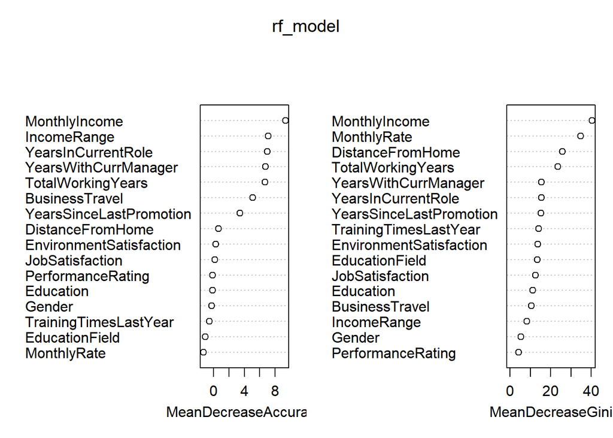

```r
rf_data <- hr_data1
rf_data <- rf_data %>%
  mutate(Attrition = as.factor(Attrition)) %>%
  mutate(BusinessTravel = if_else(BusinessTravel == "Travel_Rarely", 1, if_else(BusinessTravel == "Travel_Frequently", 2, 0))) %>%
  mutate(EducationField = if_else(EducationField == "Life Sciences", 1, if_else(EducationField == "Marketing", 2, if_else(EducationField == "Technical Degree", 3, if_else(EducationField == "Medical", 4, if_else(EducationField == "Human Resources", 5, if_else(EducationField == "Other", 6, 0))))))) %>%
  mutate(IncomeRange = case_when(
  MonthlyIncome >= 0 & MonthlyIncome < 2000 ~ 1,
  MonthlyIncome >= 2000 & MonthlyIncome < 4000 ~ 2,
  MonthlyIncome >= 4000 & MonthlyIncome < 6000 ~ 3,
  MonthlyIncome >= 6000 & MonthlyIncome < 8000 ~ 4,
  MonthlyIncome >= 8000 ~ 5
)) %>%
  mutate(Gender = if_else(Gender == "Female", 2, 1)) %>%
  select(Attrition, BusinessTravel, Education, EducationField, IncomeRange, TotalWorkingYears, TrainingTimesLastYear, YearsInCurrentRole, YearsSinceLastPromotion, YearsWithCurrManager, MonthlyIncome, MonthlyRate, Gender, DistanceFromHome, JobSatisfaction, EnvironmentSatisfaction, PerformanceRating)

set.seed(110)
indexes <- sample(1:nrow(rf_data), size = 0.7*nrow(rf_data))
train_data <- rf_data[indexes,]
test_data <- rf_data[-indexes,]

rf_model <- randomForest(Attrition ~ ., train_data, importance = TRUE, ntree = 300)
result <- varImpPlot(rf_model)
```

```r
rf_model
```

```
##
## Call:
##  randomForest(formula = Attrition ~ ., data = train_data, importance = TRUE,      ntree = 300)
##                Type of random forest: classification
##                      Number of trees: 300
## No. of variables tried at each split: 4
##
##         OOB estimate of  error rate: 15.16%
## Confusion matrix:
##      No Yes class.error
## No  864   8 0.009174312
## Yes 148   9 0.942675159
```

```r
result
```

```
##                         MeanDecreaseAccuracy MeanDecreaseGini
## BusinessTravel                     5.1062135        10.581398
## Education                         -0.1746911        11.168020
## EducationField                    -1.0678788        13.347805
## IncomeRange                        7.0909123         8.182136
## TotalWorkingYears                  6.7043409        23.642239
## TrainingTimesLastYear             -0.5482600        14.182273
## YearsInCurrentRole                 6.9706300        15.495695
## YearsSinceLastPromotion            3.3886265        15.130876
## YearsWithCurrManager               6.7588212        15.566255
## MonthlyIncome                      9.3510007        40.333938
## MonthlyRate                       -1.3277516        34.801401
## Gender                            -0.2640225         5.394840
## DistanceFromHome                   0.6178794        25.814385
## JobSatisfaction                    0.1460487        12.644458
## EnvironmentSatisfaction            0.2903920        13.594088
## PerformanceRating                 -0.1368536         4.235408
```